# Ambulatorial (SIA-PA)

Detecção ambulatorial de EIM · core vs envelope · traçadoras · taxas por UF · 2010–2025

2.472.113

registros core (EIM nomeados)

619.525

registros limítrofe (inespecíficos)

51.843.334

registros envelope (teto de subcodificação)

32

subgrupos EIM no core

R$ 639.354.633

valor aprovado (core)

O SIA-PA capta o **acompanhamento ambulatorial crônico** dos EIM. Trabalhamos com **três camadas**: o **core** (2.472.113 registros, CID-10 nomeados de EIM — o núcleo de códigos que identificam um EIM de fato), a **limítrofe** (619.525 registros — códigos de EIM porém inespecíficos, do tipo “não especificado”) e o **envelope** (51.843.334 registros — sobretudo **E78 dislipidemia**, doença comum), que é ~21× o core e serve apenas como **teto de subcodificação (*bracketing*)** — **nunca** contado como caso de EIM. Os termos *core*, *envelope* e *bracketing* estão definidos no Glossário.

O número de destaque do SIA é, portanto, um **intervalo**: 2.472.113 (core) **a** 54.934.972 (core + limítrofe + envelope).

**Detecção/uso, não prevalência.** Cada registro é uma **linha de produção ambulatorial**, não uma pessoa (o SIA-PA público não tem identificador de paciente). O envelope é o **limite superior** do que a subcodificação poderia esconder, não uma estimativa de casos.

**Diferença de definição vs SIH (ref. auditoria de 2026-08-28).** A camada é atribuída pelo **primeiro** CID-10 EIM válido entre `pa_cidpri` (principal), `pa_cidsec` (secundário) e `pa_cidcas` (causa associada) — não só o principal. Isso evita que um registro capturado só por diagnóstico secundário/causa associada fique sem camada e suma da contagem, mas o SIA “core” **não é** estritamente comparável ao “AIH com EIM principal” do SIH (que usa só `diag_princ`). Na prática o efeito é pequeno: os registros preenchidos por campo secundário/causa associada são a minoria (o campo principal já classifica a maior parte); ver detalhamento em `scripts/get_eim_data_from_SIA.R`.

## Core vs envelope — a escala do *bracketing*

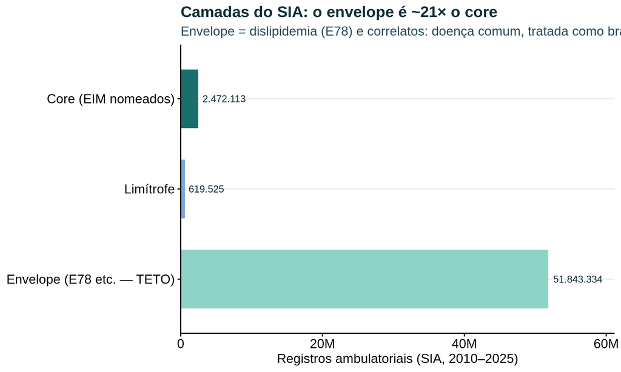

## Traçadoras no ambulatorial

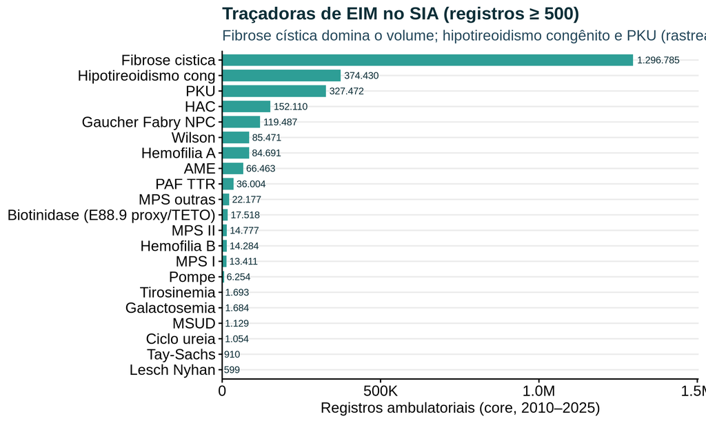

**Perfil de traçadoras difere por base** — não é ruído, é a **janela seletiva** por gravidade/sobrevivência (SIA = crônicos acompanhados). **Biotinidase** é codificada pelo MS em **E88.9** (balde inespecífico do envelope) e reportada à parte como proxy/TETO. Os rótulos CID-10 de 4 caracteres foram **auditados** contra a estrutura da CID-10 (`scripts/eim_lookup.R`); resta confirmar apenas E88.4 na tabela oficial DATASUS V2008.

## Estrutura etária e por sexo dos registros

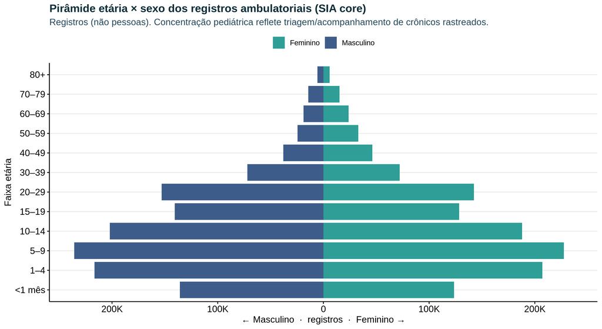

**Registros, não pessoas.** A pirâmide conta **linhas de produção ambulatorial**; a mesma criança acompanhada gera muitos registros/ano. A idade no SIA vem em **anos inteiros** e é mal preenchida — a barra `<1 mês` × `1–11 m` é **frágil** (ver limitações).

## Quantos pacientes? Contagem pelo CNS das APAC

O SIA-PA não traz identificador do paciente, mas as **APAC de medicamentos (AM) e de laudos diversos (AD)** trazem o Cartão Nacional de Saúde **criptografado**, estável entre meses, anos e arquivos. Cada APAC do PA foi ligada à AM/AD pelo número da autorização (98,5% dos registros de APAC de EIM ligados), o que permite contar **pacientes distintos**, sem estimativa e sem intervalo: são **32.475 pacientes** com APAC de EIM (camada core) em 2010–2025, dos quais 12.972 tiveram APAC em 2024. Quem só aparece em consulta ou exame (BPA, sem APAC) não entra nesta contagem.

| Subgrupo | Pacientes (2010–2025) | Pacientes em 2024 | Registros de APAC | Registros por paciente | % ligados ao CNS |
| --- | --- | --- | --- | --- | --- |
| fibrose cistica | 11.528 | 5.255 | 1.012.587 | 87,8 | 98,5 |
| aminoacidopatia PKU | 3.994 | 2.116 | 248.138 | 62,1 | 99,1 |
| hiperplasia adrenal cong | 3.758 | 1.242 | 113.529 | 30,2 | 99,1 |
| hipotireoidismo congenito | 3.384 | 0 | 7.582 | 2,2 | 93,6 |
| metab cobre | 2.215 | 773 | 80.966 | 36,6 | 98,3 |
| esfingolipidose outras | 2.180 | 1.006 | 111.545 | 51,2 | 98,7 |
| amiloidose familiar | 1.798 | 1.023 | 35.384 | 19,7 | 96,4 |
| mucopolissacaridose | 1.206 | 771 | 39.100 | 32,4 | 98,8 |
| glicogenose | 393 | 197 | 3.461 | 8,8 | 97,6 |
| galactosemia | 375 | 112 | 1.161 | 3,1 | 98,2 |
| faod | 327 | 77 | 1.228 | 3,8 | 94,2 |
| acuduria organica | 228 | 59 | 858 | 3,8 | 96,5 |
| aminoacidopatia tirosina | 218 | 43 | 793 | 3,6 | 100,0 |
| aminoacidopatia hiperfenil | 193 | 35 | 1.494 | 7,7 | 98,8 |
| glicoproteinose | 192 | 35 | 676 | 3,5 | 95,3 |

Paciente = CNS criptografado distinto nas APAC de medicamentos e de laudos diversos, ligado ao PA pelo número da APAC. O CNS é usado só para contar (LGPD): nenhum dado individual sai do processamento. Não inclui quem só tem consulta ou exame (BPA). Supressão N<5.

**E o pseudo-ID usado até o Ciclo 4?** Aplicado aos mesmos registros de APAC, o intervalo do pseudo-ID continha o número verdadeiro em 18 de 27 subgrupos, com erro mediano de 16,7% na estimativa central. No Brasil, a central **superestimava** em todos os subgrupos testados (7,3% a 45,2%): a mesma pessoa, com município, raça/cor ou idade inconsistentes entre registros, virava duas. Por isso a contagem pelo CNS substitui o pseudo-ID para quem tem APAC. Detalhes nas Notas de lançamento.

## Procedimentos SIGTAP mais frequentes

Cada registro carrega um **procedimento SIGTAP** (`pa_proc_id`). Os mais frequentes revelam o que o SUS de fato faz por esses pacientes: **medicamentos de alto custo** (alfadornase e pancreatina na fibrose cística; imiglucerase na Gaucher; tafamidis na amiloidose; fórmulas metabólicas na PKU), **consultas especializadas** e **exames diagnósticos** (dosagem de cloreto no suor — teste diagnóstico da fibrose cística).

| Cód. SIGTAP | Procedimento | Registros | Valor aprovado (R$) |
| --- | --- | --- | --- |
| 0604440014 | Alfadornase 2,5 mg (por ampola) | 403.723 | R$ 322.955.018 |
| 0301120048 | Acompanhamento de paciente com hipotireoidismo congenito | 332.298 | R$ 9.072.360 |
| 0604580029 | Pancreatina 25000 ui (por capsula) | 267.671 | R$ 127.061.303 |
| 0604580010 | Pancreatina 10.000 ui (por capsula) | 235.437 | R$ 49.377.446 |
| 0604060025 | Complemento alimentar p/ paciente fenilcetonurico maior de 1 ano - formula de aminoacidos isenta de | 232.261 | R$ 0 |
| 0302040021 | Atendimento fisioterapeutico em paciente com transtorno respiratorio sem complicacoes sistemicas | 105.846 | R$ 890.524 |
| 0604420013 | Fludrocortisona 0,1 mg (por comprimido) | 101.406 | R$ 0 |
| 0202110141 | Dosagem de cloreto no suor | 83.009 | R$ 12.599.100 |
| 0604240031 | Imiglucerase 400 u injetavel (por frasco-ampola) | 82.624 | R$ 0 |
| 0301120013 | Acompanhamento de paciente com fenilcetonuria | 72.232 | R$ 1.996.115 |
| 0604560010 | Penicilamina 250 mg (por capsula) | 71.991 | R$ 28.875.775 |
| 0604810016 | Tobramicina 300mg/5 ml solucao inalatoria (por ampola) | 44.967 | R$ 0 |
| 0604540060 | Tafamidis 20 mg capsula | 34.359 | R$ 0 |
| 0301120021 | Acompanhamento de paciente com fibrose cistica | 30.000 | R$ 819.115 |
| 0301010072 | Consulta medica em atencao especializada | 27.886 | R$ 279.287 |

Nomes via tabela SIGTAP (microdatasus::sigtab). Códigos sem correspondência marcados [VERIFICAR nome SIGTAP]. Dispensação de alto custo, consultas e exames dominam.

## Tendência ambulatorial

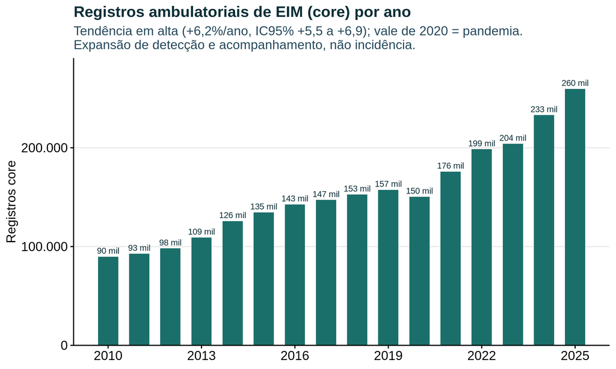

## Taxa de detecção ambulatorial padronizada por UF

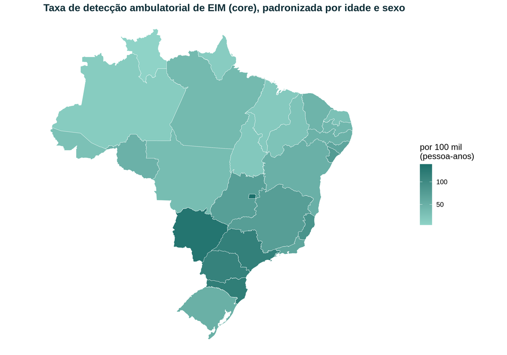

A detecção ambulatorial varia fortemente por UF — padrão dominado por **oferta de serviços especializados, centros de referência e triagem**. A variação geográfica mede em grande parte **acesso**, não incidência da doença.

## Limitações

- **Idade no SIA é mal preenchida** (`pa_idade` frequentemente ausente/agregada) — a padronização por idade usa o que há, e a estratificação etária no SIA é **frágil**; preferir SIM/SINASC para inferência sobre idade.
- **Registros ≠ pessoas** (sem identificador de paciente).
- **Envelope é teto, não caso**; nunca somar ao core nem às outras bases.
- Detecção/uso, **não prevalência**; variação por UF reflete acesso.